# Mann-Whitney Test Using JASP

Mann-Whitney Test Using JASP

## When to use a Mann-Whitney Test

A Mann-Whitney test is used to assess whether the values of an Ordinal outcome variable differ between two groups.

**Example:**

We might ask participants if they agree with a statement in a questionnaire, responding using a 5-point Likert scale:

1. Strongly Disagree
2. Disagree
3. Neither disagree nor agree
4. Agree
5. Strongly Agree

We wish to see if males agree more than females or vice-versa.

These coded responses 1 to 5 do not represent a scale but instead are ordered categories and so that data is Ordinal.

**Comparing groups for ordinal outcomes**

Since we want to compare two groups for an ordinal outcome we could use a Mann-Whitney test. To compare more than two groups, consider using a Kruskal Wallis test.

A Mann-Whitney test can also be used when the outcome variable is Scale (e.g. calorie intake or blood pressure etc.) but a better test would be a Two Sample t-test. However, that t-test test makes an assumption about normality and if that assumption is in doubt, then a Mann-Whitney test would be a good alternative.

For more help on “What test do I need” go to the **sigma** website [statistical worksheets resources](https://libguides.coventry.ac.uk/c.php?g=712076&p=5146769) page.

## Example

A study asked participants to rate various aspects of a new mobile phone, on an ordinal scale of 1 to 10 where 1 indicated they felt this aspect had “low importance”, up to 10 to indicate “high importance”. The data shown below can be downloaded in a CSV file called phone.csv and shows columns for the rating scores for price, ease of use, look, etc.

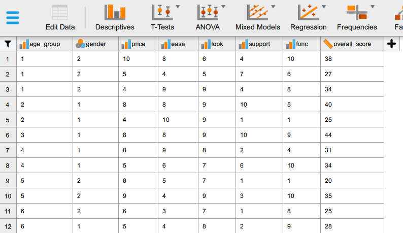

We are interested in whether the price rating tends to be higher or lower amongst males compared to females. Since the price score is Ordinal and we wish to compare two groups we should use a Mann-Whitney test.

## Using JASP

To perform the Mann-Whitney test, from the Main Menu, click the **T-Tests** menu then select **Independent Samples T-Tests**:

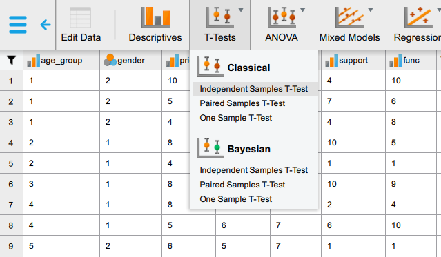

Move Price Score (the outcome variable) to the **Dependent Variables** box. Next, move gender to the **Grouping Variable** box. Under **Tests**, untick **Student** and tick **Mann-Whitney**.

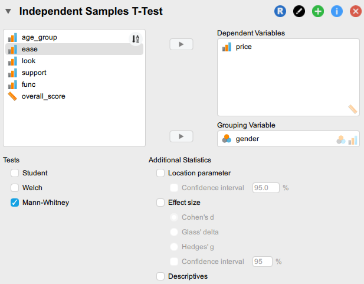

## Examining the Output

The Research Question is: Is there a difference in the price scores for males and females?

The Mann-Whitney test answers this by testing the hypotheses:

H0: There is no difference in the distribution of price scores

H1: There is a difference in the distribution of price scores

The table below provides the main results of our test:

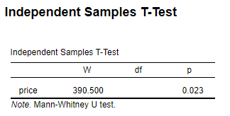

The column labelled **p** provides you with your p-value which is 0.023. This is less than 0.05 so there is evidence in favour of H1 that is there is a difference in the price scores between males and females.

To see if males or females tended to rate price more importantly, you can obtain the median scores as follows:

From the **Main Menu**, click the **Descriptives** menu. Place price in the **Variables** box and gender to the **Split** box.

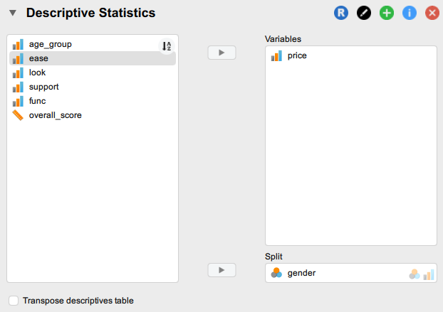

Under the **Statistics** tab, tick **Median** under **Central tendency**.

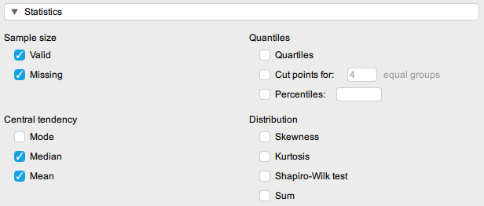

The table in the output looks as follows:

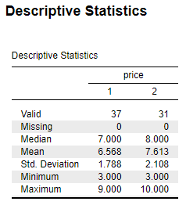

## Reporting Results

We could write the results as:

*“A Mann-Whitney t-test was used to compare the price scores for males and females. The difference was statistically significant (p = 0.023) and females tended to score price as more important (Median = 8) compared to males (Median = 7).“*

## Closing Note

Whilst we often report medians in the results section when using a Mann-Whitney test, the test does not formally test whether there is a difference in the medians between the two groups, despite large amounts of information on the internet incorrectly suggesting it does. The test actually compares the distribution of the Ordinal outcome between two groups.

For more resources, see sigma.coventry.ac.uk Adapted from material developed by Coventry University